[figure not shown]

*Tuesday, February 10th, 2026*

# Complementary reference materials recommended based on the lrRNA-seq analysis session

*Vinicius Maracaja-Coutinho* <sup>**,1,2,3*</sup> and Bárbara Borges <sup>+,1,2</sup>

> ***Principal Investigator** ─ Bioinformatics PhD

> <sup>+</sup>Biotechnologist ─ Bioinformatics MSc(c)

<sup>1</sup>*Laboratory of Integrative Bioinformatics (LIB), Unidad de Genómica Avanzada, Universidad de Chile*

<sup>2</sup>*Bioinformatics Multidisciplinary Environment (BioME), UFRN, Brazil*

<sup>3</sup>*Laboratory of Precision Medicine and Health, Fiocruz Salvador, Brazil*

**Warning**

This material is not mandatory for the course, these are only recommendations for personal studies.

If you are interested, we also have some content recommendations about long-read sequencing and RNA biology. Many of these contents are the base that was combined with our lab’s experience to build this session.

## Collection of materials per thematic

### Books, courses and tutorials to learn R and tidyverse

In the main orientations, we have recommended you the book “R for data science: Import, Tidy, Transform, Visualize, and Model Data”<sup>1</sup> (read it online for free [here](https://r4ds.hadley.nz/)). But there is also:

1. **Data science in a box**

   Contains the complete materials for teaching a semester-long introductory data science course. It is an undergraduate level introductory data science course composed by slide decks, videos, homework assignments, guided labs, sample exams, a final project assignment, as well as materials for instructors. Access the website [here](https://datasciencebox.org/).
2. **Statistical Inference via Data Science: A ModernDive into R and the Tidyverse (2e)**<sup>2</sup>

   Provides a pathway for learning about statistical inference using data science tools. It introduces the tidyverse suite of R packages. The book then covers traditional introductory statistics topics like confidence intervals, hypothesis testing, and multiple regression modeling, while focusing on visualization throughout. Acsess the website of the online free version of this book [here](https://moderndive.com/index.html).
3. **ggplot2: Elegant Graphics for Data Analysis (3e work in progress)**

   Here you will see in a wider depth the ggplot2 visualization system. “*While this book gives some details on the basics of ggplot2, its primary focus is explaining the Grammar of Graphics that ggplot2 uses, and describing the full details. It is not a cookbook, and won’t necessarily help you create any specific graphic that you need. But it will help you understand the details of the underlying theory, giving you the power to tailor any plot specifically to your needs.*”, say the authors. Access the website of the online free version of this book [here](https://ggplot2-book.org/).
4. **R Graphics Cookbook (2e)**<sup>3</sup>

   Well if you are actually needing a cookbook for R graphics, here it is. *“[…] a practical guide that provides more than 150 recipes to help you generate high-quality graphs quickly, without having to comb through all the details of R’s graphing systems. Each recipe tackles a specific problem with a solution you can apply to your own project, and includes a discussion of how and why the recipe works.”, say the authors.* Access the website of the online free version of this book [here](https://r-graphics.org/).

### If you like Markdown, VSCode, Google Colab, Jupyter and/or RStudio…

[VSCode](https://code.visualstudio.com/), [Google Colab](https://colab.google/), [Jupyter](https://jupyter.org/) and [RStudio](https://posit.co/products/open-source/rstudio/?sid=1) are some of the most used IDEs for code development. In all of them, you can use [Markdown](https://www.markdownguide.org/). Well, if you like them, I am sure you will also love the [Positron](https://positron.posit.co/) IDE (it is visually, like a merge between VSCode and RStudio) and [Quarto](https://quarto.org/) (.qmd) formats – an open-source scientific and technical publishing system built on Pandoc markdown. You can weave together narrative text and code (Python, R, Julia, Observable, etc) to produce elegantly formatted output as documents, web pages, blog posts, books and more. It is really useful for well formatted bioinformatics notebooks, and you can work with it in VSCode, JupyterLab, RStudio IDE, or any text editor under the engines of Jupyter and [Knitr](https://yihui.org/knitr/).

### Current long-read sequencing technologies

#### YouTube playlists

- Oxford Nanopore’s official [technology videos](https://youtube.com/playlist?list=PLxpxXZj-IgXyR0it4QjoBETC5JeEanW-o&si=6fYGwy_-nO6rqNmB), [sequencing in action](https://youtube.com/playlist?list=PLxpxXZj-IgXyCUNjDfNTwqml4720VrWT_&si=fv2Um3wMKJ3HApHs) and [masterclass](https://youtube.com/playlist?list=PLxpxXZj-IgXyns9e-Qmrt4DtKa32V4aLA&si=s1Ew8y_bV4l17ILe) playlists.  
- PacBio’s official [Introduction to HiFi long-read sequencing](https://youtube.com/playlist?list=PLFAB87D059EC592E9&si=v0JCKLnJO_h4CyH0), [expert insigths and workflows](https://youtube.com/playlist?list=PLg_lLlVNO_Ogu1XJwAto_GKq3S_BekhQH&si=ZXSz58Mk6bqRwq23) and [webinar](https://youtube.com/playlist?list=PLg_lLlVNO_OgbV1WbJsbJpCW2hV7QK6WC&si=bHTAFESFftGIOVEw) playlists.

#### Papers

1. [Transcriptomics in the era of long-read sequencing](https://www.nature.com/articles/s41576-025-00828-z) (2025)<sup>4</sup>
2. [Long-read RNA sequencing: A transformative technology for exploring transcriptome complexity in human diseases](https://linkinghub.elsevier.com/retrieve/pii/S1525001624007524)(2025)<sup>5</sup>
3. [The ENCODE4 long-read RNA-seq collection reveals distinct classes of transcript structure diversity](https://www.biorxiv.org/content/10.1101/2023.05.15.540865v1) (2023 / preprint)<sup>6</sup>
4. [RNA modifications detection by comparative Nanopore direct RNA sequencing](https://www.nature.com/articles/s41467-021-27393-3) (2021)<sup>7</sup>
5. [Nanopore native RNA sequencing of a human poly(A) transcriptome](https://www.nature.com/articles/s41592-019-0617-2) (2019)<sup>8</sup>

### Latest benchmarkings and standardized workflows for long-read RNA-seq

#### Papers

1. [A systematic benchmark of Nanopore long-read RNA sequencing for transcript-level analysis in human cell lines](https://www.nature.com/articles/s41592-025-02623-4) (2025)<sup>9</sup>

   **Don’t miss**

   <sub>This paper officially publishes the SG-NEx consortium and the nf-core/nanoseq pipeline.</sub>
2. [scnanoseq: an nf-core pipeline for Oxford Nanopore single-cell RNA-sequencing](https://academic.oup.com/bioinformatics/article/41/9/btaf487/8247965) (2025)<sup>10</sup>
3. [Systematic assessment of long-read RNA-seq methods for transcript identification and quantification](https://www.nature.com/articles/s41592-024-02298-3) (2024)<sup>11</sup>

   **Don’t miss**

   <sub>This paper officially publishes the LRGASP Consortium and tests various sequencing methods, and evaluates the implementation of a myriad of context-specific tools and workflows for long-read RNA-seq analysis.</sub>
4. [Benchmarking long-read RNA-sequencing analysis tools using in silico mixtures](https://www.nature.com/articles/s41592-023-02026-3) (2023)<sup>12</sup>

#### Standardized workflows

1. [nf-core/nanoseq](https://nf-co.re/nanoseq/3.1.0/) (nextflow pipeline – recently published and last update on 2023)
2. [nf-core/scnanoseq](https://nf-co.re/scnanoseq/1.2.1/) (nextflow pipeline – recently published and last updated on 2025)
3. [ENCODE’s long-read RNA-seq pipeline](https://github.com/ENCODE-DCC/long-read-rna-pipeline/tree/dev) (WDL/Docker pipeline – last update on 2023)
4. [LongNonCoder pipeline](https://github.com/integrativebioinformatics/longnoncoder) (our lab’s under development nextflow pipeline – last commit on 2025)

   **Note**

   <sub>The pipeline is on its final steps for the official 1st release, but it is already available and running since Dec, 2025</sub>

### Best data publicly available collections and consortiums of long-read RNA-seq data

#### SG-NEx project

The [Singapore Nanopore Expression Project](https://github.com/GoekeLab/sg-nex-data) (SG-NEx) is an international collaboration initiated at the Genome Institute of Singapore to provide reference transcriptomes for 5 of the most commonly used cancer cell lines using Nanopore long read RNA-Seq data.

#### LRGASP Consortium

The [LRGASP Consortium](https://www.gencodegenes.org/pages/LRGASP/) is organizing a systematic evaluation of different methods for transcript computational identification and quantification using long-read sequencing technologies such as PacBio and Oxford Nanopore. They are interested in characterizing the strengths and potential remaining challenges in using these technologies to annotate and quantify the transcriptomes of both model and non-model organisms. The [GENCODE Project](https://www.gencodegenes.org/) (Encyclopædia of genes and gene variants), a sub-project of [ENCODE](https://www.genome.gov/Funded-Programs-Projects/ENCODE-Project-ENCyclopedia-Of-DNA-Elements), endorses the LRGASP initiative, and you can find the LRGASP datasets of total 24 samples for human and mouse long-read RNA-seq at the [ENCODE Portal](https://www.encodeproject.org/search/?type=Experiment&internal_tags=LRGASP).

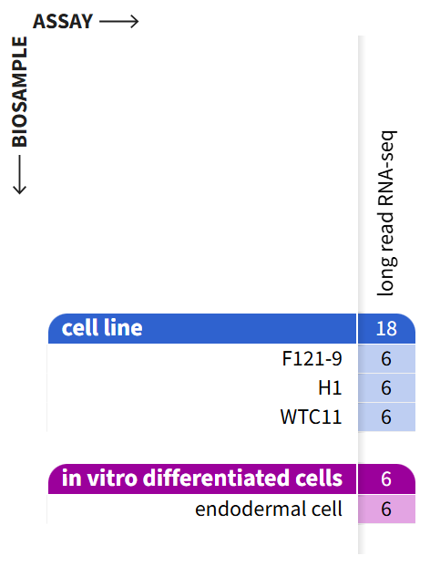

This image belongs to the ENCODE Portal’s Experiment Matrix search for the LRGASP consortium. It was generated by filtering data for: a) Assay title: long-read RNA-seq b) Organism: Human and Mouse; c) Provenance: community.

#### ENCODE Project

[The Encyclopedia of DNA Elements (ENCODE)](https://www.genome.gov/Funded-Programs-Projects/ENCODE-Project-ENCyclopedia-Of-DNA-Elements) is a public research consortium aimed at identifying all functional elements in the human and mouse genomes. The ENCODE project is one of the most important initiatives for many of the last great discoveries about human and mice that contributed for transcriptomics evolution. By browsing the [ENCODE Portal](https://www.encodeproject.org/) we can quickly find 232 valuable samples from the official project that were sequenced by long-read technology, including long-read single-cell RNA-seq. These samples are publicly available, and it is possible to retrieve them for analysis.

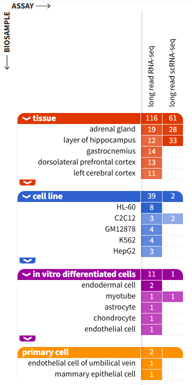

This image belongs to the ENCODE Portal’s Experiment Matrix search . It was generated by filtering data for: a) Assay title: long-read RNA-seq and long-read scRNA-seq; b) Organism: Human and Mouse; c) Provenance: ENCODE

### Other interesting bioinformatics resources

#### Tidyomics

You read upstream about how tidyR was very important, right? Therefore, now you can get to know tidyomics. The tidyomics ecosystem is a set of packages for ’omic data analysis that work together in harmony; they share common data representations and API design, consistent with the tidyverse ecosystem. The tidyomics package is designed to make it easy to install and load core packages from the tidyomics ecosystem with a single command.

Read the brief communication from 2024 “[The tidyomics ecosystem: enhancing omic data analyses](https://www.nature.com/articles/s41592-024-02299-2)”.<sup>13</sup>

#### Isoformic

[Isoformic](https://github.com/luciorq/isoformic) is a R-built workflow for isoform-level biological interpretation of transcriptomic data. The workflow uses known annotated transcripts to produce biologically relevant results based on the different types of transcripts for any comparison of case versus control transcriptomic data. While developed based on short-read data applications, it is possible to use it for long-reads as well.

Read the paper from 2025 “[Isoformic: a workflow for transcript-level RNA-seq interpretation](https://academic.oup.com/nargab/article/7/4/lqaf176/8363848)”<sup>14</sup>

### RNA biology book

Our final reading documentation is the book **“RNA, the Epicenter of Genetic Information”**<sup>15</sup> written by John Mattick and Paulo Amaral.  
The e-book for kindle might be free on [Amazon](https://a.co/d/c2kow3w) (at least in Brazil)  
The PDF and EPUB versions are also available for open access at the Taylor & Francis Group website.  
If you wish to buy the physical printed book, it is available at [Amazon](https://a.co/d/atqE9q1) and [Routledge](https://www.routledge.com/RNA-the-Epicenter-of-Genetic-Information/Amaral-Mattick/p/book/9780367623920?_ga=undefined).

### That’s it!

We hope you enjoy all of the recommendations we have prepared for you.

**Last important note**

If you have any doubts or require any special accessibility assistance about this document or the course, do not hesitate to contact us.

**Contact both of us through e-mail**

mbarborgess@gmail.com

vinicius.maracaja@uchile.cl

Se you all very soon 😊

Best regards,

*Vinicius Maracajá-Coutinho and Bárbara Borges*

## References

1.

Wickham, H., Çetinkaya-Rundel, M. & Grolemund, G. *[R for data science](https://books.google.com.br/books?id=UCLEEAAAQBAJ)*. (O’Reilly Media, 2023).

2.

Ismay, C. & Kim, A. Y. *[Statistical inference via data science: A ModernDive into r and the tidyverse](https://books.google.com.br/books?id=SWHGDwAAQBAJ)*. (CRC Press, 2019).

3.

Chang, W. *[R graphics cookbook: Practical recipes for visualizing data](https://books.google.com.br/books?id=Ud50DwAAQBAJ)*. (O’Reilly Media, 2018).

4.

Monzó, C., Liu, T. & Conesa, A. [Transcriptomics in the era of long-read sequencing](https://doi.org/10.1038/s41576-025-00828-z). *Nature Reviews Genetics* **26**, 681–701 (2025).

5.

Ament, I. H., DeBruyne, N., Wang, F. & Lin, L. [Long-read RNA sequencing: A transformative technology for exploring transcriptome complexity in human diseases](https://doi.org/10.1016/j.ymthe.2024.11.025). *Molecular Therapy* **33**, 883–894 (2025).

6.

Reese, F. *et al.* [The ENCODE4 long-read RNA-seq collection reveals distinct classes of transcript structure diversity](http://dx.doi.org/10.1101/2023.05.15.540865). (2023).

7.

Leger, A. *et al.* [RNA modifications detection by comparative Nanopore direct RNA sequencing](https://doi.org/10.1038/s41467-021-27393-3). *Nature Communications* **12**, (2021).

8.

Workman, R. E. *et al.* [Nanopore native RNA sequencing of a human poly(A) transcriptome](https://doi.org/10.1038/s41592-019-0617-2). *Nature Methods* **16**, 1297–1305 (2019).

9.

Chen, Y. *et al.* [A systematic benchmark of Nanopore long-read RNA sequencing for transcript-level analysis in human cell lines](https://doi.org/10.1038/s41592-025-02623-4). *Nature Methods* **22**, 801–812 (2025).

10.

Trull, A., Worthey, E. A. & Ianov, L. [scnanoseq: an nf-core pipeline for Oxford Nanopore single-cell RNA-sequencing](https://doi.org/10.1093/bioinformatics/btaf487). *Bioinformatics* **41**, (2025).

11.

Pardo-Palacios, F. J. *et al.* [Systematic assessment of long-read RNA-seq methods for transcript identification and quantification](https://doi.org/10.1038/s41592-024-02298-3). *Nature Methods* **21**, 1349–1363 (2024).

12.

Dong, X. *et al.* [Benchmarking long-read RNA-sequencing analysis tools using in silico mixtures](https://doi.org/10.1038/s41592-023-02026-3). *Nature Methods* **20**, 1810–1821 (2023).

13.

Hutchison, W. J. *et al.* [The tidyomics ecosystem: enhancing omic data analyses](https://doi.org/10.1038/s41592-024-02299-2). *Nature Methods* **21**, 1166–1170 (2024).

14.

Mamede, I. *et al.* [Isoformic: a workflow for transcript-level RNA-seq interpretation](https://doi.org/10.1093/nargab/lqaf176). *NAR Genomics and Bioinformatics* **7**, (2025).

15.

Mattick, J. & Amaral, P. *RNA, the Epicenter of Genetic Information*. (CRC Press - Taylor & Francis Group, 2022). doi:10.1201/9781003109242.